# Module–Trait Association — Frontal Cortex (Bulk RNA-seq)

Extended Analysis: Age, FTD/AD Comorbidity, Site of Motor Onset

ALS Deconvolution Project

2026-04-28

> **What this analysis adds:** The original WGCNA module–trait analysis included only four traits: ALS status, sex, RIN (RNA quality), and C9ORF72 expansion status. This extended analysis adds three new trait categories:
> - **Age at Death** — Tests whether any co-expression module is correlated with subject age, which could confound ALS associations.
> - **FTD/AD Comorbidity** — A binary indicator (1 = present, 0 = absent) flagging any subject whose `Subject.Group.Subcategory` mentions Frontotemporal Dementia (FTD) or Alzheimer’s Disease (AD). This captures the subset of ALS patients with concurrent neurodegeneration.
> - **Site of Motor Onset** — Three binary indicator columns encoding the canonical onset region:
>   - **Onset_Limb**: includes Limb, Lower/Upper Limb, Lower/Upper Extremity, Upper and Lower Limbs, combined entries (e.g., “Bulbar and Limb”), and Generalized.
>   - **Onset_Bulbar**: includes Bulbar, combined entries, and Generalized.
>   - **Onset_Axial**: includes Axial, combined entries, and Generalized.
>   - Rows with “Not Applicable”, “Unknown”, blank, or “Dementia onset” receive 0 for all three columns.

**Dataset:** Frontal Cortex — Bulk RNA-seq | **Retained samples:** 116 | **Non-grey modules:** 77

# 1 Metadata Encoding

Summary of new trait encoding (full cohort vs WGCNA-retained samples)

| Category | Full cohort (n) | Retained in WGCNA (n) |
| --- | --- | --- |
| FTD/AD Comorbidity (= 1) | 41 | 18 |
| FTD/AD Absent (= 0) | 301 | 98 |
| Onset: Limb (= 1) | 196 | 70 |
| Onset: Bulbar (= 1) | 84 | 29 |
| Onset: Axial (= 1) | 12 | 6 |
| Age: available (non-NA) | 337 | 114 |

**Onset categories in retained samples:**

| Original value | n | Canonical category |
| --- | --- | --- |
| Axial and Bulbar | 2 | Axial + Bulbar |
| Axial and Limb | 2 | Axial + Limb |
| Axial | 2 | Axial only |
| Bulbar and Limb | 4 | Bulbar + Limb |
| Bulbar | 23 | Bulbar only |
| Limb | 64 | Limb only |
| Not Applicable | 12 | Not encoded (0) |
| Unknown | 7 | Not encoded (0) |

# 2 Full Module–Trait Heatmap

All 77 non-grey modules × 9 traits. Colour encodes Pearson correlation (red = positive, blue = negative). Stars indicate significance level.

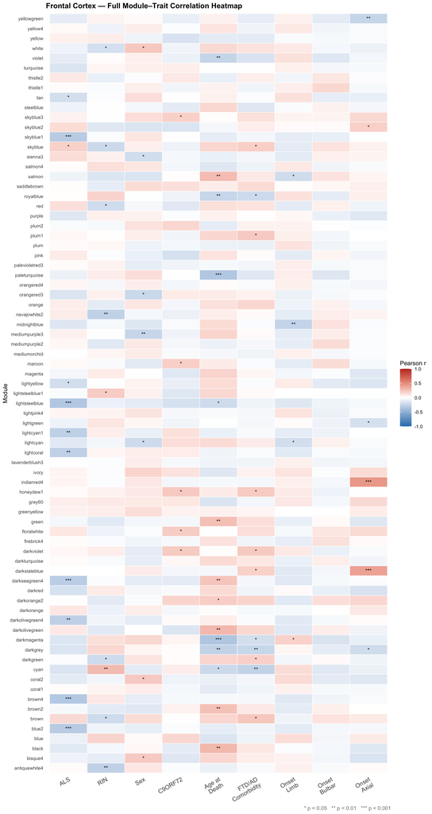

# 3 Filtered Modules: ALS p < 0.05 and RIN p > 0.05

**10 module(s) passed the filter** (ALS p < 0.05 and RIN p > 0.05):

Filtered modules: ALS-significant and RIN-independent

| Module | r (ALS) | p (ALS) | r (RIN) | p (RIN) | r (Age) | p (Age) | r (FTD/AD) | p (FTD/AD) | Direction |
| --- | --- | --- | --- | --- | --- | --- | --- | --- | --- |
| brown4 | -0.335 | 0.000236 | 0.093 | 0.322 | -0.036 | 0.70100 | -0.042 | 0.654 | DOWN in ALS ↓ |
| lightsteelblue | -0.346 | 0.000145 | -0.078 | 0.404 | -0.216 | 0.02000 | -0.070 | 0.456 | DOWN in ALS ↓ |
| skyblue1 | -0.315 | 0.000568 | -0.023 | 0.806 | -0.103 | 0.27200 | -0.052 | 0.579 | DOWN in ALS ↓ |
| blue2 | -0.316 | 0.000542 | -0.068 | 0.466 | -0.106 | 0.25800 | -0.061 | 0.518 | DOWN in ALS ↓ |
| lightcoral | -0.282 | 0.002190 | 0.039 | 0.676 | -0.066 | 0.48300 | -0.022 | 0.812 | DOWN in ALS ↓ |
| darkolivegreen4 | -0.284 | 0.001980 | -0.061 | 0.514 | 0.065 | 0.48600 | -0.023 | 0.803 | DOWN in ALS ↓ |
| darkseagreen4 | -0.304 | 0.000891 | -0.014 | 0.878 | 0.241 | 0.00919 | -0.049 | 0.603 | DOWN in ALS ↓ |
| lightyellow | -0.198 | 0.033300 | 0.004 | 0.970 | 0.145 | 0.12100 | -0.022 | 0.814 | DOWN in ALS ↓ |
| tan | -0.194 | 0.037100 | -0.011 | 0.905 | 0.055 | 0.55800 | -0.018 | 0.848 | DOWN in ALS ↓ |
| lightcyan1 | -0.288 | 0.001710 | 0.070 | 0.453 | -0.093 | 0.32200 | -0.033 | 0.727 | DOWN in ALS ↓ |

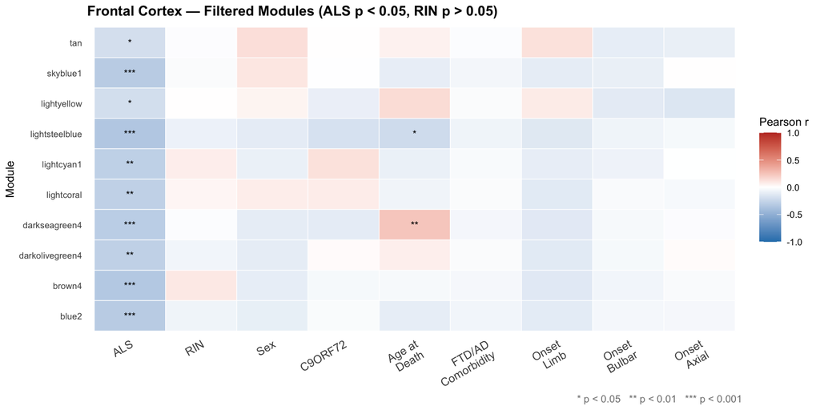

# 4 ALS Association Direction — Bar Graph

For each filtered module, bars show −log₁₀(ALS p-value) × sign(ALS correlation). Positive bars = module **up-regulated** in ALS; negative bars = module **down-regulated** in ALS. The dashed lines mark the p = 0.05 threshold.

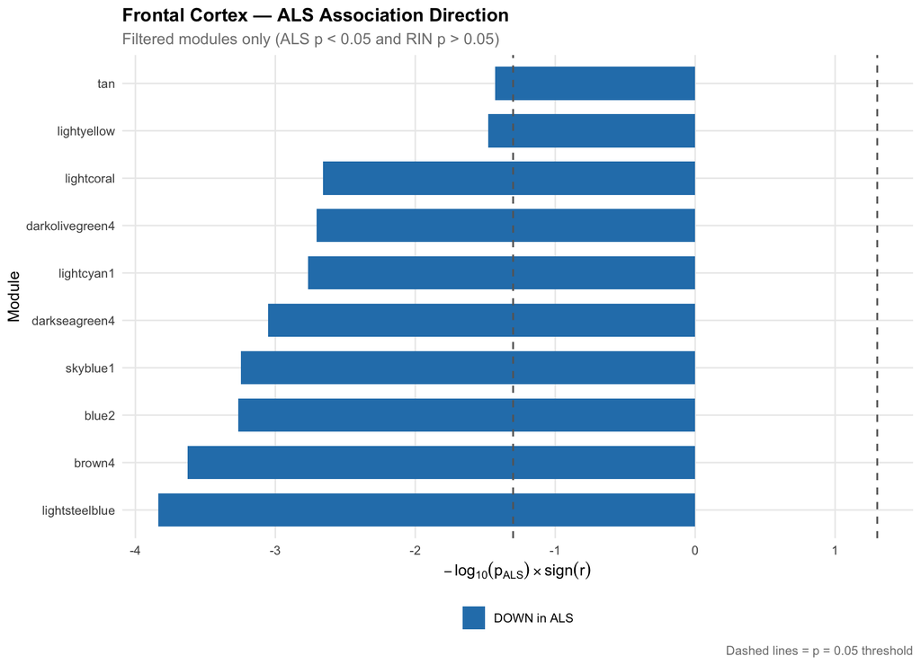

# 5 Summary & Brief Analysis

**10 module(s)** survived the dual filter in the Frontal Cortex: **0 up-regulated** and **10 down-regulated** in ALS, independent of RNA quality.

Key observations:

- Modules passing this filter show a genuine ALS-associated transcriptional signature in bulk frontal cortex tissue, not explained by differential RNA degradation (RIN).
- Additional traits (Age, FTD/AD comorbidity, Site of Motor Onset) reveal whether these modules also associate with disease heterogeneity — a module correlated with both ALS *and* bulbar onset, for instance, may reflect distinct disease biology.
- Modules correlated with FTD/AD comorbidity should be interpreted cautiously, as they may reflect mixed neurodegeneration rather than pure ALS biology.

*Generated by `FC_Subset_Analysis.Rmd` | WGCNA module structure from existing bulk Frontal Cortex network | Extended trait matrix: ALS, RIN, Sex, C9ORF72, Age, FTD/AD, Onset (Limb/Bulbar/Axial)*